# Appendix S2 - GAM modelling

Appendix S2 - GAM modelling Noori, S. et al. 14 July 2020

## Packages

First, we will load all required packages.

```r
### General
library(sf)    # load shp and add centroids
library(corrplot) # multicollinearity

### GAM modelling and model selection
library(mgcv)  # gam model
library(bbmle) # AICtab
library(MuMIn) # Weight for Akaike Weight


### Model evaluation
library(broom)  # glance
library(modEvA) # Dsquared
library(gratia) # plotting GAMs
library(sjPlot) # final summary table


#### Spatial Autocorrelation (SAC)
library(gstat) # variograms + bubble plot
library(sp)    # spatial data handling
library(spdep) # Morans I
library(ncf)   # SAC correlogram
```

## Reptiles at 4000 km²

```r
## read shapefile with sf
hex_env <- read_sf("F:/Sajad_Iran/tmp/hex_pam_4000.shp")


## add X Y coordinates in meters with EPSG 6931
mycentroids <- st_transform(hex_env, 6931) %>%
  st_centroid() %>%
  #    this is the crs from d, which has no EPSG code:
  st_transform(., '+proj=longlat +ellps=WGS84 +no_defs') %>%
  #   since you want the centroids in a second geometry col:
  st_geometry()
df2 = data.frame(st_coordinates(mycentroids))


## add coordinates to sf
hex_env$X<-df2$X
hex_env$Y<-df2$Y


### remove an outlier in correlation measure
hex_env <- subset(hex_env, corr > 1000)

### put correlation measure on log-scale
hex_env$corr <- log(hex_env$corr)

## make data.frame for modelling
envonly <- st_drop_geometry(hex_env)
envonly <- envonly[,-1]
```

Next, we will analyse the multicollinearity of the data using Pearson’s correlation coefficient.

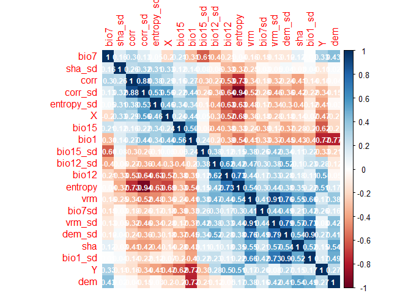

```r
M <- cor(envonly[,-c(17:18)],use = "pairwise.complete.obs")


corrplot(cor(envonly[,-c(17:18)],
         use = "pairwise.complete.obs"),
         method = "color",
         addCoef.col="white",
         order = "AOE",
         number.cex=0.75,
         tl.cex = 1 )
```

As this plot is hard to read, we will restrict the figure to values beyond r = abs(0.75).

[figure not shown]

By looking at these two figures, we see that the standard deviation (sd) values often correlate more or less strong with the mean values. Hence, we ignore the sd values from now on. Bio1 is correlated with Y and dem, while entropy is correlated with corr_sd. Dem_sd correlates with measures that describe topographical heterogeneity (i.e. vrm, vrm_sd), but also variation in temperature. As we do not allow the models to consider all predictors (we have too few data points for this) multicollinearity is only a problem when parameters from the same “theme” (climate, topography, habitat heterogeneity) are considered.

We continue with building the GAM models. For this, we create a null model which uses only the mean richness value per cell. We will use the null model for baseline comparisons. No model should be worse than a null model. Then, we calculate a model for each single parameter but always including the spatial interaction of the coordinates as this has several advantages such as reduced SAC, cleaner residuals, and better predictive performance. The spatial interactions accounts for large scale trends in unmeasured parameters.

```r
### GAM models ----------
### null model
S.intercept <- gam(Sobs ~ 1, data = envonly, family = "nb", method = "REML", select = TRUE)

### single parameter models
S.bio1 <- gam(Sobs ~ s(X, Y, bs = "sos") + s(bio1) , data = envonly, family = "nb", method = "REML", select = TRUE)

S.bio12 <- gam(Sobs ~ s(X, Y, bs = "sos") + s(bio12) , data = envonly, family = "nb", method = "REML", select = TRUE)

S.bio7 <- gam(Sobs ~ s(X, Y, bs = "sos") + s(bio7) , data = envonly, family = "nb", method = "REML", select = TRUE)

S.bio15 <- gam(Sobs ~ s(X, Y, bs = "sos") + s(bio15) , data = envonly, family = "nb", method = "REML", select = TRUE)

S.dem <- gam(Sobs ~ s(X, Y, bs = "sos") + s(dem) , data = envonly, family = "nb", method = "REML", select = TRUE)

S.entropy <- gam(Sobs ~ s(X, Y, bs = "sos") + s(entropy) , data = envonly, family = "nb", method = "REML", select = TRUE)

S.corr <- gam(Sobs ~ s(X, Y, bs = "sos") + s(corr) , data = envonly, family = "nb", method = "REML", select = TRUE)

S.sha <- gam(Sobs ~ s(X, Y, bs = "sos") + s(sha) , data = envonly, family = "nb", method = "REML", select = TRUE)

S.vrm <- gam(Sobs ~ s(X, Y, bs = "sos") + s(vrm) , data = envonly, family = "nb", method = "REML", select = TRUE)

### thematic models
S.clim <- gam(Sobs ~ s(X, Y, bs = "sos") + s(bio1) +s(bio12) + s(bio7) + s(bio15) , data = envonly, family = "nb", method = "REML", select = TRUE)

S.topo <- gam(Sobs ~ s(X, Y, bs = "sos") + s(dem) + s(sha) + s(vrm) , data = envonly, family = "nb", method = "REML", select = TRUE)

S.hetero <- gam(Sobs ~ s(X, Y, bs = "sos") + s(entropy) + s(corr) , data = envonly, family = "nb", method = "REML", select = TRUE)
```

After model building, we will evaluate the models by calculating the AIC for each model, sorting these according to delta AIC values and also add the Akaike Weights for better interpretation. Further we will calculate D², a synonym for R² in a generalized model context.

```r
# build AIC table
Sobs.models <- list(S.intercept = S.intercept,
                    S.bio1  = S.bio1,
                    S.bio12 = S.bio12,
                    S.bio7  = S.bio7,
                    S.bio15 = S.bio15,
                    S.dem = S.dem,
                    S.entropy = S.entropy,
                    S.corr = S.corr,
                    S.vrm = S.vrm,
                    S.sha = S.sha,
                    S.clim = S.clim,
                    S.topo = S.topo,
                    S.hetero = S.hetero)

### calculate model summary
tmp.glance <-plyr::ldply(Sobs.models,glance)
tmp.d2     <-plyr::ldply(Sobs.models,Dsquared)
tmp.glance$D2<-round(tmp.d2[,2],3)
tmp.glance
```

```
##            .id       df    logLik      AIC      BIC deviance df.residual    D2
## 1  S.intercept  1.00000 -1208.480 2420.959 2428.957 419.4955    402.0000 0.000
## 2       S.bio1 35.83096 -1128.824 2338.250 2499.410 379.9410    367.1690 0.322
## 3      S.bio12 33.77526 -1133.631 2345.377 2501.564 383.2094    369.2247 0.305
## 4       S.bio7 32.61238 -1136.239 2344.000 2487.006 384.4199    370.3876 0.296
## 5      S.bio15 33.01367 -1134.471 2341.385 2486.231 384.4103    369.9863 0.302
## 6        S.dem 32.61122 -1136.241 2343.986 2486.957 384.4230    370.3888 0.296
## 7    S.entropy 32.06923 -1130.374 2334.784 2482.814 381.9693    370.9308 0.317
## 8       S.corr 30.95719 -1137.614 2348.408 2494.729 383.3577    372.0428 0.292
## 9        S.vrm 32.61160 -1136.241 2343.988 2486.965 384.4230    370.3884 0.296
## 10       S.sha 34.37965 -1130.438 2337.516 2490.754 382.7208    368.6204 0.316
## 11      S.clim 37.85009 -1122.984 2335.463 2514.405 377.5934    365.1499 0.341
## 12      S.topo 34.72766 -1129.884 2338.789 2496.786 382.0241    368.2723 0.318
## 13    S.hetero 36.28856 -1117.448 2317.062 2481.348 376.2319    366.7114 0.359
```

```r
#make AIC tab
Sobs.AIC<-AICtab(Sobs.models)
Sobs.AIC$AW<- round(Weights(Sobs.AIC$dAIC),3)
Sobs.AIC$df <- round(Sobs.AIC$df,3)
Sobs.AIC
```

```
##             dAIC  df     AW
## S.hetero      0.0 41.083   1.0
## S.entropy    17.7 37.017   0.0
## S.clim       18.4 44.748   0.0
## S.sha        20.5 38.32    0.0
## S.bio1       21.2 40.301   0.0
## S.topo       21.7 39.51    0.0
## S.bio15      24.3 36.221   0.0
## S.dem        26.9 35.752   0.0
## S.vrm        26.9 35.754   0.0
## S.bio7       26.9 35.761   0.0
## S.bio12      28.3 39.057   0.0
## S.corr       31.3 36.59    0.0
## S.intercept 103.9 2        0.0
```

The best model is clearly the thematic model of habitat heterogeneity. The following model summary shows the significance of the smoothers as well as further information on the model. The theta value (3.833) shows us that slight overdispersion effect was handled by the negative binomial distribution.

```r
### summary table
summary(S.hetero)
```

```
##
## Family: Negative Binomial(3.833)
## Link function: log
##
## Formula:
## Sobs ~ s(X, Y, bs = "sos") + s(entropy) + s(corr)
##
## Parametric coefficients:
##             Estimate Std. Error z value Pr(>|z|)
## (Intercept)  1.94954    0.03206   60.81   <2e-16 ***
## ---
## Signif. codes:  0 '***' 0.001 '**' 0.01 '*' 0.05 '.' 0.1 ' ' 1
##
## Approximate significance of smooth terms:
##                edf Ref.df Chi.sq  p-value
## s(X,Y)     30.3069     49 111.70 2.62e-14 ***
## s(entropy)  4.0445      9  35.68 3.14e-10 ***
## s(corr)     0.9372      9  10.24 0.000337 ***
## ---
## Signif. codes:  0 '***' 0.001 '**' 0.01 '*' 0.05 '.' 0.1 ' ' 1
##
## R-sq.(adj) =  0.279   Deviance explained = 35.9%
## -REML = 1185.2  Scale est. = 1         n = 403
```

We will now predict the model to the hexagonal grid and compare the observed and predicted values.

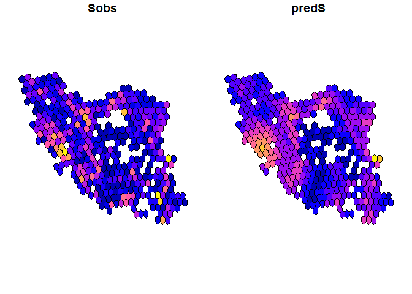

```r
##create new dataframe to predict to
newdf = hex_env[c("X","Y","entropy","corr")]
newdf <- st_drop_geometry(newdf)
newdf <- as.data.frame(newdf)

## predict on the response scale (richness counts)
hex_env$predS<-predict.gam(object=S.hetero, newdata = newdf,type="response")

## plot the observed and predicted pattern
plot(hex_env[c("Sobs","predS")])
```

```r
## compare the summary values
summary(hex_env$Sobs) # Observed reptile richness
```

```
##    Min. 1st Qu.  Median    Mean 3rd Qu.    Max.
##   1.000   3.000   6.000   7.717  11.000  29.000
```

```r
summary(hex_env$predS) # Predicted reptile richness
```

```
##    Min. 1st Qu.  Median    Mean 3rd Qu.    Max.
##   2.150   5.554   7.612   7.558   9.281  18.026
```

```r
## correlation between predicted and observed
cor.test(hex_env$predS, hex_env$Sobs,method = "pearson")
```

```
##
##  Pearson's product-moment correlation
##
## data:  hex_env$predS and hex_env$Sobs
## t = 14.89, df = 401, p-value < 2.2e-16
## alternative hypothesis: true correlation is not equal to 0
## 95 percent confidence interval:
##  0.5299012 0.6561394
## sample estimates:
##       cor
## 0.5966995
```

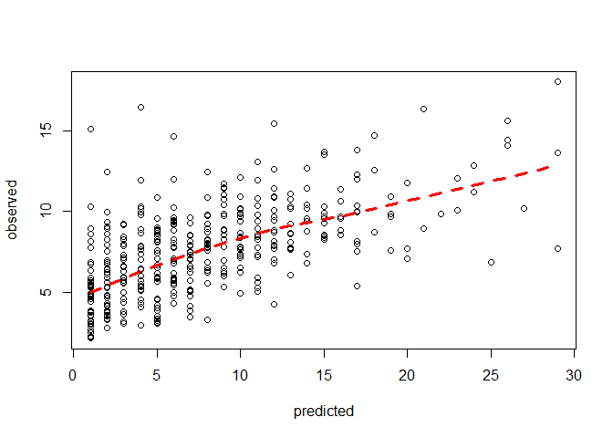

```r
## plot the relationship
scatter.smooth(hex_env$Sobs,hex_env$predS, lpars=list(col="red", lwd=3,lty=2),
               xlab="predicted",ylab="observed")
```

Now we need to assess the validity of the model using diagnostic plots and displays of the smoothers.

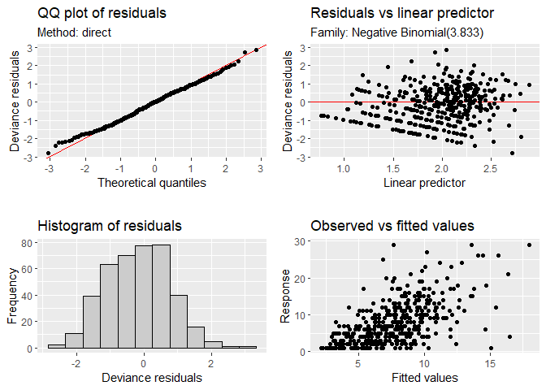

```r
## using methods from the gratia package
## diagnostic plots
appraise(S.hetero)
```

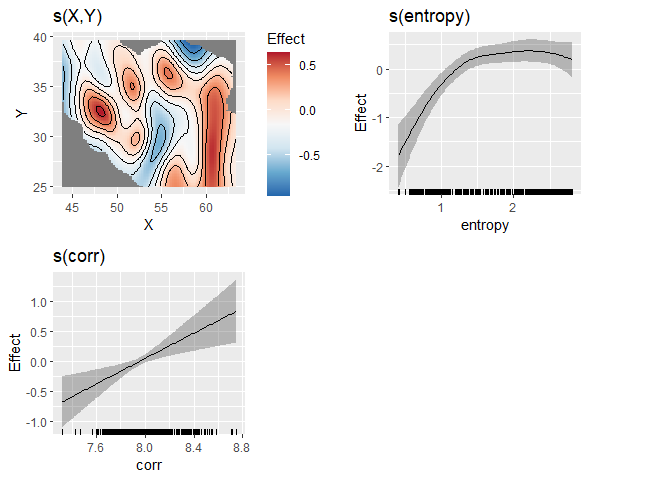

```r
## plot the smoothers
draw(S.hetero,residuals = F)
```

The diagnostic plots look good. But as we are doing spatial explicit modelling, we should now check the model residuals for potential effects of spatial autocorrelation.

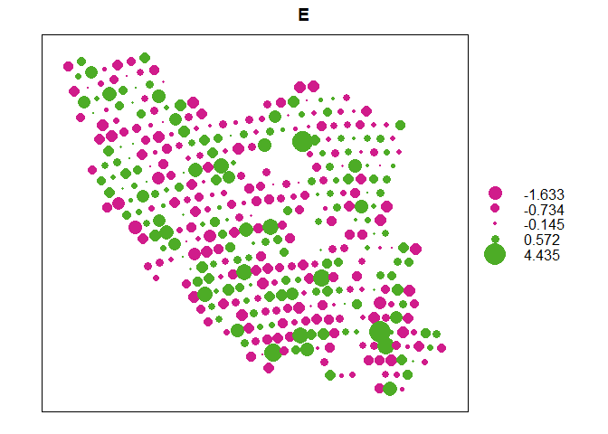

```r
### extract the residuals
E<-(resid(S.hetero,type="scaled.pearson"))
newdf2 <- newdf ## make copy of newdf
mydata <- data.frame(E=E, X=newdf2$X,Y=newdf2$Y)
coordinates(mydata) <- ~ X + Y
proj4string(mydata) = CRS("+init=epsg:4326") ## set WGS84 as CRS

### mydata is now spatial object

## bubble plot
bubble(mydata,"E")
```

```r
## isotropic variogram
E.vgm<- variogram(E~ X+Y, mydata)
E.vgm
```

```
##      np      dist     gamma dir.hor dir.ver   id
## 1  1094  71.78052 0.8853981       0       0 var1
## 2  1971 132.44875 0.9664702       0       0 var1
## 3  2133 188.79646 0.9191554       0       0 var1
## 4  2560 238.84861 0.9188313       0       0 var1
## 5  2967 290.32174 0.9212217       0       0 var1
## 6  3673 347.21870 0.8749834       0       0 var1
## 7  3722 404.67172 0.8554711       0       0 var1
## 8  3798 460.00094 0.8765292       0       0 var1
## 9  3679 512.06201 0.9049448       0       0 var1
## 10 3925 563.72887 0.8711505       0       0 var1
## 11 4086 618.07151 0.9168547       0       0 var1
## 12 4218 673.98902 0.8865603       0       0 var1
## 13 4063 729.18598 0.8949556       0       0 var1
## 14 3895 782.20255 0.8828725       0       0 var1
```

```r
E.fit = fit.variogram(E.vgm, model = vgm(1, "Sph", 900, 1))
E.fit
```

```
##   model     psill range
## 1   Nug 0.9110249     0
## 2   Sph 0.0000000   900
```

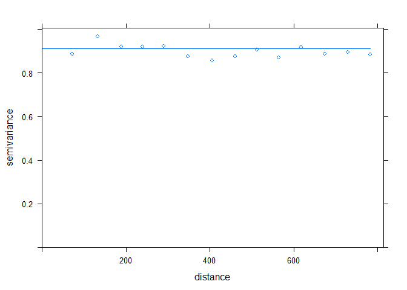

```r
plot(E.vgm, E.fit)
```

```r
## anisotropic variogram
E.vgm<- variogram(E~ X+Y, mydata, alpha=c(0,45,90,135))
E.vgm
```

```
##      np      dist     gamma dir.hor dir.ver   id
## 1   188  75.34615 0.9522155       0       0 var1
## 2   475 139.77942 1.0148884       0       0 var1
## 3   527 203.50618 0.9776520       0       0 var1
## 4   338 248.33725 0.9480212       0       0 var1
## 5   616 281.34376 0.9423423       0       0 var1
## 6   878 344.07736 0.8599001       0       0 var1
## 7   931 408.59221 0.8396676       0       0 var1
## 8   782 468.92495 0.8770764       0       0 var1
## 9   662 516.58470 0.7672522       0       0 var1
## 10  715 557.24799 0.8367368       0       0 var1
## 11  912 613.89397 0.8936895       0       0 var1
## 12  910 675.13215 0.8992573       0       0 var1
## 13  821 734.40364 0.9393779       0       0 var1
## 14  661 785.60750 0.9174352       0       0 var1
```

[output cut: 42 more lines]

```r
E.fit = fit.variogram(E.vgm, model = vgm(1, "Sph", 900, 1, anis = c(45, 0.5)))
E.fit
```

```
##   model     psill range ang1 anis1
## 1   Nug 0.9002711     0    0   1.0
## 2   Sph 0.0000000   900   45   0.5
```

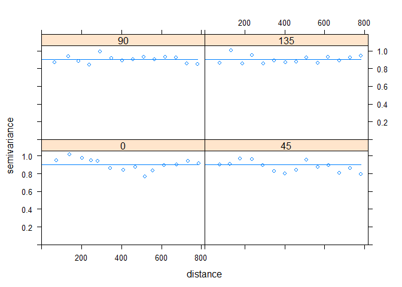

```r
plot(E.vgm, E.fit)
```

```r
### Morans'I Correlogram
ncf.cor <- correlog(mydata$X, mydata$Y, mydata$E, increment=100, resamp=999,latlon=T)
```

```
## 100  of  999
200  of  999
300  of  999
400  of  999
500  of  999
600  of  999
700  of  999
800  of  999
900  of  999
```

```r
#### number of samples per lag and mean distance of lag in km
ncf.cor$n # number of observations per lag
```

```
##    1    2    3    4    5    6    7    8    9   10   11   12   13   14   15   16
## 1007 3386 5509 6002 7128 7089 7658 7266 7326 6590 5979 4613 3531 2499 1767 1261
##   17   18   19   20   21   22   23
##  882  622  414  259  151   53   11
```

```r
ncf.cor$mean.of.class # mean km per lag
```

```
##          1          2          3          4          5          6          7
##   68.76174  149.32453  251.24207  352.91817  451.15233  550.95174  650.14838
##          8          9         10         11         12         13         14
##  749.77545  848.72721  948.43280 1048.28589 1148.67171 1248.17375 1347.92031
##         15         16         17         18         19         20         21
## 1447.52856 1547.22109 1647.39260 1747.21847 1847.45625 1946.63416 2044.01932
##         22         23
## 2144.04069 2228.66659
```

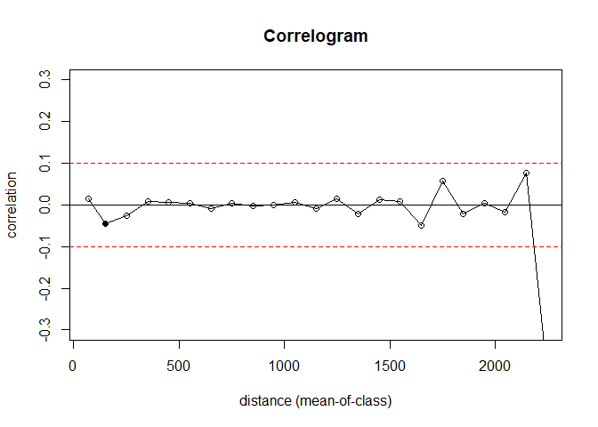

```r
### plotting the correlogram
plot(ncf.cor, ylim=c(-0.3,0.3))
abline(h=0); abline(h=-0.1, col="red", lty=2); abline(h=0.1, col="red", lty=2)
```

The model did not show any specific SAC pattern in the residuals. Hence, we can conclude that this is a clean best model we can derive from the given candidate data set. We will save the model in an extra object, so we can reuse the object names.

```r
### save model to final object
best4000 <- S.hetero
```

## Reptiles at 8000 km²

After having successfully modeled the reptile richness of Iran on a scale of 4000 km² we will now increase the spatial scale to 8000 km². We will rerun the same steps as we did for the first model. However, we will not explain every single step, but only where it is necessary or where it becomes interesting.

First comes the data preparation:

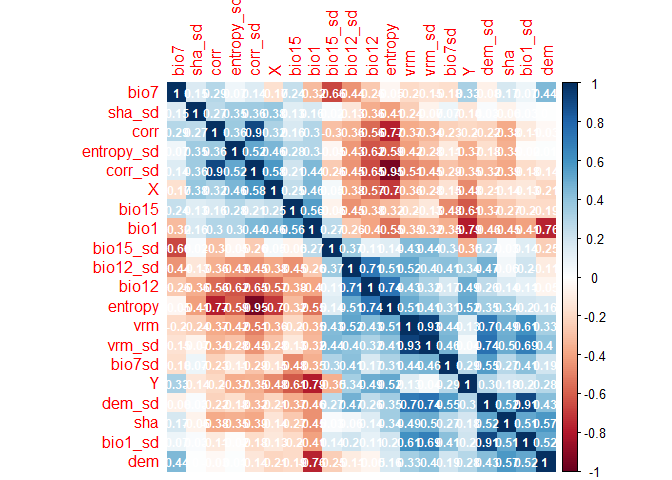

```r
## read shp
hex_env <- read_sf("F:/Sajad_Iran/tmp/hex_pam_8000.shp")

## add X Y coordinates in meters
mycentroids <- st_transform(hex_env, 6931) %>%
  st_centroid() %>%
  #    this is the crs from d, which has no EPSG code:
  st_transform(., '+proj=longlat +ellps=WGS84 +no_defs') %>%
  #   since you want the centroids in a second geometry col:
  st_geometry()
df2 = data.frame(st_coordinates(mycentroids))

## add coordinates to shp
hex_env$X<-df2$X
hex_env$Y<-df2$Y


### remove outlier in correlation measure
hex_env <- subset(hex_env, corr > 1000)
hex_env$corr <- log(hex_env$corr)

## make data.frame for modelling
envonly <- st_drop_geometry(hex_env)
envonly <- envonly[,-1]


#### multicollinearity
M <- cor(envonly[,-c(17:18)],use = "pairwise.complete.obs")

corrplot(cor(envonly[,-c(17:18)],
             use = "pairwise.complete.obs"),
         method = "color",
         addCoef.col="white",
         order = "AOE",
         number.cex=0.75,
         tl.cex = 1 )
```

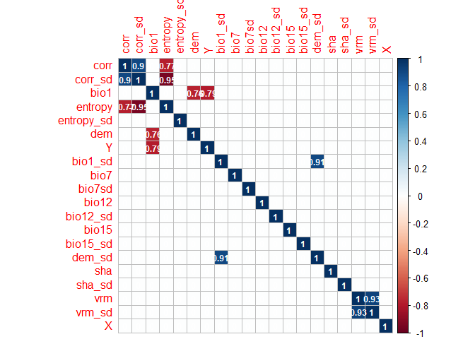

```r
tmp = M # Copy matrix
tmp[ tmp > -0.75 & tmp < 0.75 ] = 0

corrplot(tmp,
         method = "color",
         addCoef.col="white",
         order = "AOE",
         number.cex=0.75,
         tl.cex = 1,
         addgrid.col = "grey")
```

Entropy is now strongly correlated with the correlation measure. Both parameters were derived as texture measures of the EVI as a proxy for habitat heterogeneity. The correlation might become problematic in the next steps, but as it is only marginally over our original threshold, we will continue. Next comes the model building part.

```r
### GAM models ----------
S.intercept <- gam(Sobs ~ 1, data = envonly, family = "nb", method = "REML", select = TRUE)

S.bio1 <- gam(Sobs ~ s(X, Y, bs = "sos") + s(bio1) , data = envonly, family = "nb", method = "REML", select = TRUE)

S.bio12 <- gam(Sobs ~ s(X, Y, bs = "sos") + s(bio12) , data = envonly, family = "nb", method = "REML", select = TRUE)

S.bio7 <- gam(Sobs ~ s(X, Y, bs = "sos") + s(bio7) , data = envonly, family = "nb", method = "REML", select = TRUE)

S.bio15 <- gam(Sobs ~ s(X, Y, bs = "sos") + s(bio15) , data = envonly, family = "nb", method = "REML", select = TRUE)

S.dem <- gam(Sobs ~ s(X, Y, bs = "sos") + s(dem) , data = envonly, family = "nb", method = "REML", select = TRUE)

S.entropy <- gam(Sobs ~ s(X, Y, bs = "sos") + s(entropy) , data = envonly, family = "nb", method = "REML", select = TRUE)

S.corr <- gam(Sobs ~ s(X, Y, bs = "sos") + s(corr) , data = envonly, family = "nb", method = "REML", select = TRUE)

S.sha <- gam(Sobs ~ s(X, Y, bs = "sos") + s(sha) , data = envonly, family = "nb", method = "REML", select = TRUE)

S.vrm <- gam(Sobs ~ s(X, Y, bs = "sos") + s(vrm) , data = envonly, family = "nb", method = "REML", select = TRUE)

S.clim <- gam(Sobs ~ s(X, Y, bs = "sos") + s(bio1) +s(bio12) + s(bio7) + s(bio15) , data = envonly, family = "nb", method = "REML", select = TRUE)

S.topo <- gam(Sobs ~ s(X, Y, bs = "sos") + s(dem) + s(sha) + s(vrm) , data = envonly, family = "nb", method = "REML", select = TRUE)

S.hetero <- gam(Sobs ~ s(X, Y, bs = "sos") + s(entropy) + s(corr) , data = envonly, family = "nb", method = "REML", select = TRUE)



# build AIC table
Sobs.models <- list(S.intercept = S.intercept,
                    S.bio1  = S.bio1,
                    S.bio12 = S.bio12,
                    S.bio7  = S.bio7,
                    S.bio15 = S.bio15,
                    S.dem = S.dem,
                    S.entropy = S.entropy,
                    S.corr = S.corr,
                    S.vrm = S.vrm,
                    S.sha = S.sha,
                    S.clim = S.clim,
                    S.topo = S.topo,
                    S.hetero = S.hetero)

### calculate model summary
tmp.glance <-plyr::ldply(Sobs.models,glance)
tmp.d2     <-plyr::ldply(Sobs.models,Dsquared)
tmp.glance$D2<-round(tmp.d2[,2],3)
tmp.glance
```

```
##            .id       df    logLik      AIC      BIC deviance df.residual    D2
## 1  S.intercept  1.00000 -754.0389 1512.078 1518.937 241.5804    227.0000 0.000
## 2       S.bio1 10.56337 -736.3248 1500.068 1547.081 232.2434    217.4366 0.137
## 3      S.bio12 12.20032 -732.5352 1496.383 1550.073 230.5281    215.7997 0.164
## 4       S.bio7 13.12961 -731.5342 1497.289 1555.966 229.4219    214.8704 0.171
## 5      S.bio15 10.56111 -736.3282 1500.001 1546.888 232.2494    217.4389 0.137
## 6        S.dem 10.56157 -736.3277 1500.006 1546.903 232.2482    217.4384 0.137
## 7    S.entropy 13.33677 -725.5397 1484.814 1542.657 228.9182    214.6632 0.212
## 8       S.corr 12.07462 -728.2454 1487.444 1540.518 230.0472    215.9254 0.194
## 9        S.vrm 11.34322 -735.2256 1502.091 1556.342 231.4331    216.6568 0.145
## 10       S.sha 10.56259 -736.3271 1500.011 1546.919 232.2469    217.4374 0.137
## 11      S.clim 17.22594 -722.7584 1492.653 1573.477 224.8678    210.7741 0.231
## 12      S.topo 14.35422 -730.2924 1501.273 1571.039 228.4281    213.6458 0.180
## 13    S.hetero 13.62825 -721.8726 1479.976 1542.101 228.7166    214.3717 0.236
```

```r
#make AIC tab
Sobs.AIC<-AICtab(Sobs.models)
Sobs.AIC$AW<- round(Weights(Sobs.AIC$dAIC),3)
Sobs.AIC$df <- round(Sobs.AIC$df,3)
Sobs.AIC
```

```
##             dAIC df     AW
## S.hetero     0.0 18.116  0.9
## S.entropy    4.8 16.867  0.1
## S.corr       7.5 15.476  0.0
## S.clim      12.7 23.568  0.0
## S.bio12     16.4 15.656  0.0
## S.bio7      17.3 17.11   0.0
## S.bio15     20.0 13.672  0.0
## S.dem       20.0 13.675  0.0
## S.sha       20.0 13.678  0.0
## S.bio1      20.1 13.709  0.0
## S.topo      21.3 20.344  0.0
## S.vrm       22.1 15.82   0.0
## S.intercept 32.1 2       0.0
```

```r
summary(S.hetero)
```

```
##
## Family: Negative Binomial(3.592)
## Link function: log
##
## Formula:
## Sobs ~ s(X, Y, bs = "sos") + s(entropy) + s(corr)
##
## Parametric coefficients:
##             Estimate Std. Error z value Pr(>|z|)
## (Intercept)  2.36275    0.04063   58.15   <2e-16 ***
## ---
## Signif. codes:  0 '***' 0.001 '**' 0.01 '*' 0.05 '.' 0.1 ' ' 1
##
## Approximate significance of smooth terms:
##              edf Ref.df Chi.sq  p-value
## s(X,Y)     7.517     49  21.73 0.000442 ***
## s(entropy) 2.415      9  11.53 0.000693 ***
## s(corr)    2.696      9  13.04 0.000265 ***
## ---
## Signif. codes:  0 '***' 0.001 '**' 0.01 '*' 0.05 '.' 0.1 ' ' 1
##
## R-sq.(adj) =  0.195   Deviance explained = 23.6%
## -REML = 744.83  Scale est. = 1         n = 228
```

Again the thematic set of the habitat heterogeneity variables becomes the best model. We have to evaluate the model and keep in mind the correlation of the variables.

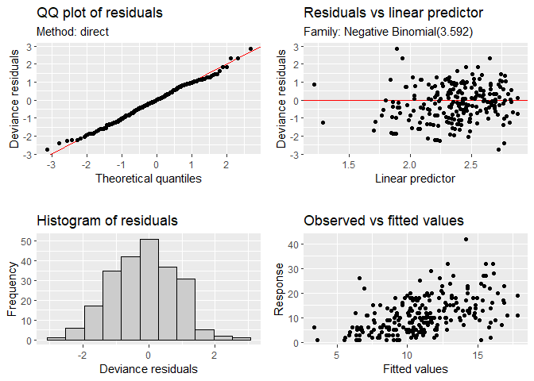

```r
### visualize with Gratia
## residuals
appraise(S.hetero)
```

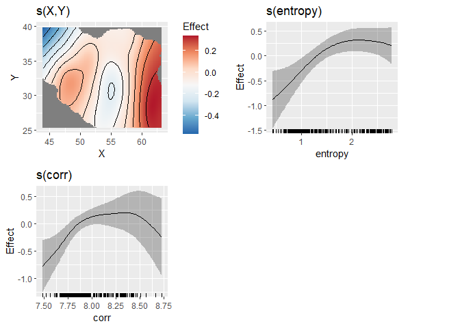

```r
## smoother
draw(S.hetero, residuals=F)
```

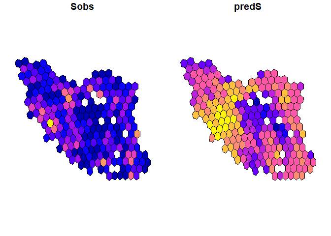

```r
## create new data set
newdf = hex_env[c("X","Y","entropy","corr")]
newdf <- st_drop_geometry(newdf)
newdf <- as.data.frame(newdf)
hex_env$predS<-predict.gam(object=S.hetero, newdata = newdf,type="response")


plot(hex_env[c("Sobs","predS")])
```

```r
summary(hex_env$Sobs)
```

```
##    Min. 1st Qu.  Median    Mean 3rd Qu.    Max.
##    1.00    5.00   10.00   11.20   15.25   42.00
```

```r
summary(hex_env$predS)
```

```
##    Min. 1st Qu.  Median    Mean 3rd Qu.    Max.
##    3.37    9.05   10.85   11.04   13.11   17.85
```

```r
cor(hex_env$Sobs,hex_env$predS)
```

```
## [1] 0.4993101
```

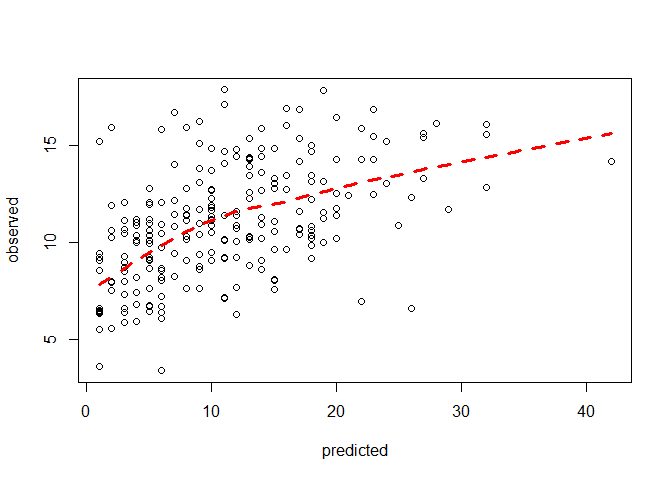

```r
scatter.smooth(hex_env$Sobs,hex_env$predS, lpars=list(col="red", lwd=3,lty=2),
               xlab="predicted",ylab="observed")
```

The model looks still adequate. We need to verify the spatial autocorrelation effects.

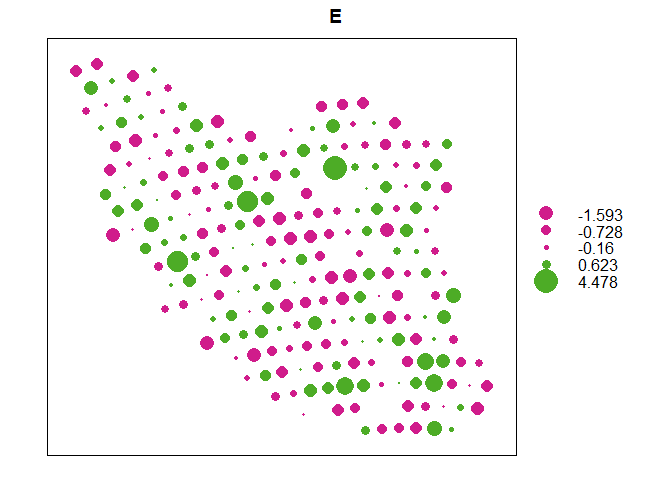

```r
E<-(resid(S.hetero,type="scaled.pearson"))
newdf2 <- newdf
mydata <- data.frame(E=E, X=newdf2$X,Y=newdf2$Y)
coordinates(mydata) <- ~ X + Y
proj4string(mydata) = CRS("+init=epsg:4326") ## set WGS84 as CRS

## bubble plot
bubble(mydata,"E")
```

```r
## isotropic variogram
E.vgm<- variogram(E~ X+Y, mydata)
E.vgm
```

```
##      np      dist     gamma dir.hor dir.ver   id
## 1   532  96.24969 0.8203023       0       0 var1
## 2   293 146.93076 1.0239126       0       0 var1
## 3   781 187.45622 0.9841827       0       0 var1
## 4   845 242.91343 1.0282694       0       0 var1
## 5  1064 302.39700 1.0150473       0       0 var1
## 6   647 344.93740 0.9757243       0       0 var1
## 7  1456 396.91005 0.9317122       0       0 var1
## 8  1149 461.30946 0.9329243       0       0 var1
## 9  1146 505.42896 0.9903460       0       0 var1
## 10 1357 561.38845 0.9568595       0       0 var1
## 11 1247 614.61298 0.9959143       0       0 var1
## 12 1350 669.95955 1.0413686       0       0 var1
## 13 1102 719.30434 0.9090983       0       0 var1
## 14 1416 773.03585 0.9433384       0       0 var1
```

```r
E.fit = fit.variogram(E.vgm, model = vgm(1, "Sph", 900, 1))
E.fit
```

```
##   model     psill    range
## 1   Nug 0.4921068   0.0000
## 2   Sph 0.4982241 143.6861
```

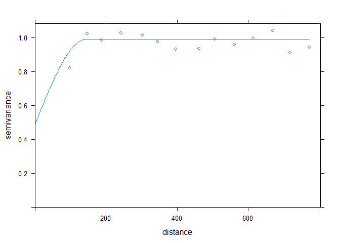

```r
plot(E.vgm, E.fit)
```

```r
## anisotropic variogram
E.vgm<- variogram(E~ X+Y, mydata, alpha=c(0,45,90,135))
E.vgm
```

```
##     np      dist     gamma dir.hor dir.ver   id
## 1   58 105.82324 0.8207667       0       0 var1
## 2   47 107.44828 1.1784163       0       0 var1
## 3  230 194.34140 0.9382678       0       0 var1
## 4   37 214.70711 0.8823472       0       0 var1
## 5  345 291.61702 1.0134450       0       0 var1
## 6   58 346.10126 0.8139123       0       0 var1
## 7  383 390.81961 0.9911445       0       0 var1
## 8  214 467.51389 0.9229911       0       0 var1
## 9  275 496.24251 0.9235337       0       0 var1
## 10 326 570.31796 0.8351446       0       0 var1
## 11 161 604.14857 0.9403987       0       0 var1
## 12 363 669.52389 1.0562314       0       0 var1
## 13 136 716.47786 0.9010809       0       0 var1
## 14 340 768.83868 1.0237668       0       0 var1
```

[output cut: 42 more lines]

```r
E.fit = fit.variogram(E.vgm, model = vgm(1, "Sph", 900, 1, anis = c(45, 0.5)))
E.fit
```

```
##   model     psill    range ang1 anis1
## 1   Nug 0.5193580   0.0000    0   1.0
## 2   Sph 0.4689635 289.1709   45   0.5
```

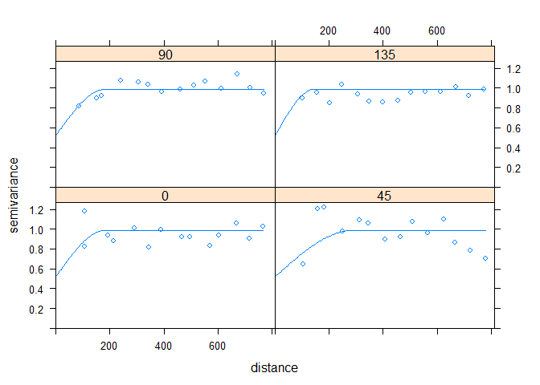

```r
plot(E.vgm, E.fit)
```

```r
### Correlgoram
ncf.cor <- correlog(mydata$X, mydata$Y, mydata$E, increment=50, resamp=999,latlon=T)
```

```
## 100  of  999
200  of  999
300  of  999
400  of  999
500  of  999
600  of  999
700  of  999
800  of  999
900  of  999
```

```r
## info
ncf.cor$n # number of observations per lag
```

```
##    2    3    4    5    6    7    8    9   10   11   12   13   14   15   16   17
##  250  334  766  787  699 1088 1169  749 1442  994 1245 1200 1290 1010 1358 1030
##   18   19   20   21   22   23   24   25   26   27   28   29   30   31   32   33
## 1149 1045 1101  842  950  778  677  677  535  437  420  322  253  251  187  160
##   34   35   36   37   38   39   40   41   42   43   44   45   46
##  142  118   97   83   65   54   39   31   23   13   11    4    3
```

```r
ncf.cor$mean.of.class # mean km per lag
```

```
##          2          3          4          5          6          7          8
##   87.48978  104.76866  170.50957  225.77356  274.59359  319.24691  382.78843
##          9         10         11         12         13         14         15
##  420.67223  475.15826  527.18557  573.93800  623.98839  677.21257  724.03959
##         16         17         18         19         20         21         22
##  774.04145  827.69944  873.33775  925.40894  975.32623 1026.15079 1072.72406
##         23         24         25         26         27         28         29
## 1127.57307 1172.32221 1224.80460 1275.70556 1323.59242 1373.50298 1427.04320
##         30         31         32         33         34         35         36
## 1472.04192 1523.81337 1575.32119 1623.68001 1674.26266 1724.83913 1774.44566
##         37         38         39         40         41         42         43
## 1824.98719 1875.18587 1923.92954 1974.74102 2024.21932 2073.78255 2120.54491
##         44         45         46
## 2170.10352 2221.29269 2266.32639
```

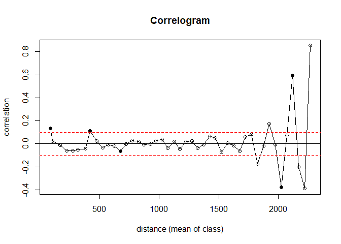

```r
## plot
plot(ncf.cor)
abline(h=0); abline(h=-0.1, col="red", lty=2); abline(h=0.1, col="red", lty=2)
```

The bubble plot shows several large residual values, which is not a big issue. The empirical variograms also do not show very concerning pictures, except the one for 45°. The correlogram however, shows a statistically significant effect in the first lag (up to 100km), and again at ca. 380km. The first lag is still within a hexagonal cell, as the long distance between the sides of a hexagon of 8000km² is 110km² (for an easy calculation try https://www.omnicalculator.com/math/hexagon). The 380km significance effect is thus about 3.5 cells away which might be already too far away for a true SAC effect. These are expected to be within the near vicinity (lag 4-7). The significant effects at the very end of the correlogram have no practical meaning. The data is too scarce at these lags.

We conclude that this model has some issues but might be regarded as acceptable.

Save best model

```r
best8000 <- S.hetero
```

## Reptiles at 20.000 km²

Finally, we will model the reptile richness of Iran at a very coarse scale of 20.000 km². This will tell us whether other predictors will become more important than the habitat heterogeneity or whether the models become more prone to multicollinearity or spatial autocorrelation effects.

We start with the data preparation and the multicollinearity check.

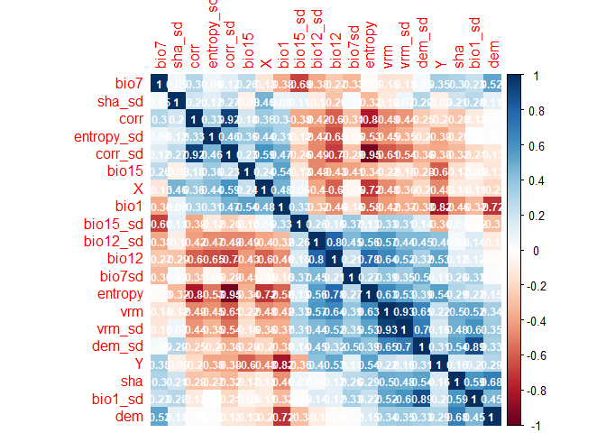

```r
## read shp
hex_env <- read_sf("F:/Sajad_Iran/tmp/hex_pam_20000.shp")

## add X Y coordinates in meters
mycentroids <- st_transform(hex_env, 6931) %>%
  st_centroid() %>%
  #    this is the crs from d, which has no EPSG code:
  st_transform(., '+proj=longlat +ellps=WGS84 +no_defs') %>%
  #   since you want the centroids in a second geometry col:
  st_geometry()
df2 = data.frame(st_coordinates(mycentroids))

## add coordinates to shp
hex_env$X<-df2$X
hex_env$Y<-df2$Y


#### remove outlier in correlation measure
hex_env <- subset(hex_env, corr > 1000)
hex_env$corr <- log(hex_env$corr)

## make data.frame for modelling
envonly <- st_drop_geometry(hex_env)
envonly <- envonly[,-1]



#### multicollinearity
M <- cor(envonly[,-c(17:18)],use = "pairwise.complete.obs")

corrplot(cor(envonly[,-c(17:18)],
             use = "pairwise.complete.obs"),
         method = "color",
         addCoef.col="white",
         order = "AOE",
         number.cex=0.75,
         tl.cex = 1 )
```

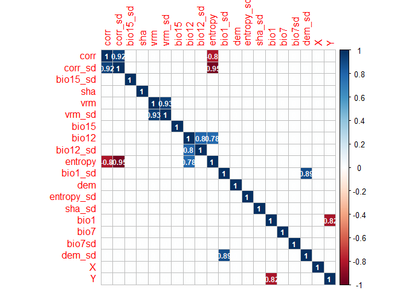

```r
tmp = M # Copy matrix
tmp[ tmp > -0.75 & tmp < 0.75 ] = 0


corrplot(tmp,
         method = "color",
         addCoef.col="white",
         order = "AOE",
         number.cex=0.75,
         tl.cex = 1,
         addgrid.col = "grey")
```

The multicollinearity effect between entropy and correlation has become even stronger. In addition, entropy has become also correlated with bio12 (mean annual rainfall). Also the other correlations have become stronger, which is interpreted as an aggregation effect due to increased cell sizes which leaves less variation.

We will continue with the model building.

```r
### GAM models ----------
S.intercept <- gam(Sobs ~ 1, data = envonly, family = "nb", method = "REML", select = TRUE)

S.bio1 <- gam(Sobs ~ s(X, Y, bs = "sos") + s(bio1) , data = envonly, family = "nb", method = "REML", select = TRUE)

S.bio12 <- gam(Sobs ~ s(X, Y, bs = "sos") + s(bio12) , data = envonly, family = "nb", method = "REML", select = TRUE)

S.bio7 <- gam(Sobs ~ s(X, Y, bs = "sos") + s(bio7) , data = envonly, family = "nb", method = "REML", select = TRUE)

S.bio15 <- gam(Sobs ~ s(X, Y, bs = "sos") + s(bio15) , data = envonly, family = "nb", method = "REML", select = TRUE)

S.dem <- gam(Sobs ~ s(X, Y, bs = "sos") + s(dem) , data = envonly, family = "nb", method = "REML", select = TRUE)

S.entropy <- gam(Sobs ~ s(X, Y, bs = "sos") + s(entropy) , data = envonly, family = "nb", method = "REML", select = TRUE)

S.corr <- gam(Sobs ~ s(X, Y, bs = "sos") + s(corr) , data = envonly, family = "nb", method = "REML", select = TRUE)

S.sha <- gam(Sobs ~ s(X, Y, bs = "sos") + s(sha) , data = envonly, family = "nb", method = "REML", select = TRUE)

S.vrm <- gam(Sobs ~ s(X, Y, bs = "sos") + s(vrm) , data = envonly, family = "nb", method = "REML", select = TRUE)

S.clim <- gam(Sobs ~ s(X, Y, bs = "sos") + s(bio1) +s(bio12) + s(bio7) + s(bio15) , data = envonly, family = "nb", method = "REML", select = TRUE)

S.topo <- gam(Sobs ~ s(X, Y, bs = "sos") + s(dem) + s(sha) + s(vrm) , data = envonly, family = "nb", method = "REML", select = TRUE)

S.hetero <- gam(Sobs ~ s(X, Y, bs = "sos") + s(entropy) + s(corr) , data = envonly, family = "nb", method = "REML", select = TRUE)


# build AIC table
Sobs.models <- list(S.intercept = S.intercept,
                    S.bio1  = S.bio1,
                    S.bio12 = S.bio12,
                    S.bio7  = S.bio7,
                    S.bio15 = S.bio15,
                    S.dem = S.dem,
                    S.entropy = S.entropy,
                    S.corr = S.corr,
                    S.vrm = S.vrm,
                    S.sha = S.sha,
                    S.clim = S.clim,
                    S.topo = S.topo,
                    S.hetero = S.hetero)

### calculate model summary
tmp.glance <-plyr::ldply(Sobs.models,glance)
tmp.d2     <-plyr::ldply(Sobs.models,Dsquared)
tmp.glance$D2<-round(tmp.d2[,2],3)
tmp.glance
```

```
##            .id        df    logLik      AIC      BIC deviance df.residual    D2
## 1  S.intercept  1.000000 -395.7546 795.5091 800.8171 113.3659   104.00000 0.000
## 2       S.bio1  1.000915 -395.7539 795.5115 800.8243 113.3645   103.99909 0.000
## 3      S.bio12  2.268223 -393.8600 795.3195 805.4039 112.1717   102.73178 0.033
## 4       S.bio7  1.001119 -395.7539 795.5122 800.8261 113.3645   103.99888 0.000
## 5      S.bio15  1.001446 -395.7534 795.5127 800.8283 113.3636   103.99855 0.000
## 6        S.dem  1.472564 -395.0864 795.6174 802.8422 112.9282   103.52744 0.012
## 7    S.entropy  5.424914 -382.7097 780.3119 800.0741 108.9341    99.57509 0.205
## 8       S.corr  3.008350 -389.6410 788.3911 800.4789 111.6688   101.99165 0.102
## 9        S.vrm 10.688495 -378.9170 788.8387 829.9812 104.8805    94.31151 0.259
## 10       S.sha  9.612595 -381.1205 790.2152 827.3365 105.8686    95.38741 0.229
## 11      S.clim  4.777104 -389.1227 792.0221 810.3036 109.9700   100.22290 0.110
## 12      S.topo 13.587323 -373.0055 784.1770 834.8224 102.5404    91.41268 0.333
## 13    S.hetero  6.048209 -382.1838 781.4805 804.1888 108.4099    98.95179 0.213
```

```r
#make AIC tab
Sobs.AIC<-AICtab(Sobs.models)
Sobs.AIC$AW <- round(Weights(Sobs.AIC$dAIC),3)
Sobs.AIC$df <- round(Sobs.AIC$df,3)
Sobs.AIC
```

```
##             dAIC df     AW
## S.entropy    0.0 7.446   0.6
## S.hetero     1.2 8.556   0.3
## S.topo       3.9 19.083  0.1
## S.corr       8.1 4.555   0.0
## S.vrm        8.5 15.502  0.0
## S.sha        9.9 13.987  0.0
## S.clim      11.7 6.888   0.0
## S.bio12     15.0 3.8     0.0
## S.intercept 15.2 2       0.0
## S.bio1      15.2 2.002   0.0
## S.bio7      15.2 2.002   0.0
## S.bio15     15.2 2.003   0.0
## S.dem       15.3 2.722   0.0
```

```r
## model summary
summary(S.entropy)
```

```
##
## Family: Negative Binomial(3.511)
## Link function: log
##
## Formula:
## Sobs ~ s(X, Y, bs = "sos") + s(entropy)
##
## Parametric coefficients:
##             Estimate Std. Error z value Pr(>|z|)
## (Intercept)  2.87348    0.05723   50.21   <2e-16 ***
## ---
## Signif. codes:  0 '***' 0.001 '**' 0.01 '*' 0.05 '.' 0.1 ' ' 1
##
## Approximate significance of smooth terms:
##                  edf Ref.df Chi.sq  p-value
## s(X,Y)     0.0004387     49   0.00    0.742
## s(entropy) 4.4244753      9  27.51 5.16e-06 ***
## ---
## Signif. codes:  0 '***' 0.001 '**' 0.01 '*' 0.05 '.' 0.1 ' ' 1
##
## R-sq.(adj) =  0.172   Deviance explained = 20.5%
## -REML =    394  Scale est. = 1         n = 105
```

The model with the single parameter entropy has become the strongest model, yet still within a close distance to the second best model, which is again the habitat heterogeneity model. WE will continue with the Entropy model, given the fact that correlation and entropy were strongly correlated so that these will not be useful in the thematic data set, and second that we should favor more parsimonious models in comparison to more complex models.

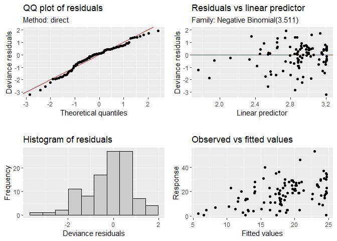

```r
### visualize with Gratia
## residuals
appraise(S.entropy)
```

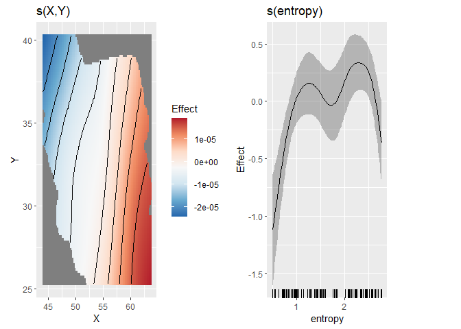

```r
## smoother
draw(S.entropy, residuals=F)
```

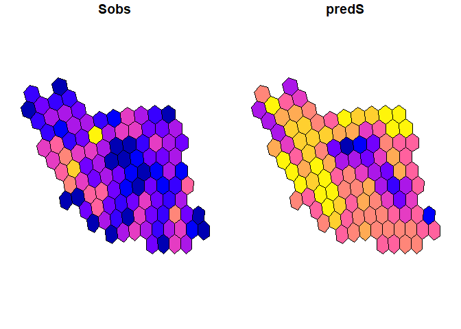

```r
## create new data set
newdf = hex_env[c("X","Y","entropy","corr")]
newdf <- st_drop_geometry(newdf)
newdf <- as.data.frame(newdf)
hex_env$predS<-predict.gam(object=S.entropy, newdata = newdf,type="response")


plot(hex_env[c("Sobs","predS")])
```

```r
summary(hex_env$Sobs)
```

```
##    Min. 1st Qu.  Median    Mean 3rd Qu.    Max.
##     1.0    11.0    19.0    18.5    25.0    53.0
```

```r
summary(hex_env$predS)
```

```
##    Min. 1st Qu.  Median    Mean 3rd Qu.    Max.
##   5.781  16.276  18.490  18.358  21.039  24.749
```

```r
cor(hex_env$Sobs,hex_env$predS)
```

```
## [1] 0.4564272
```

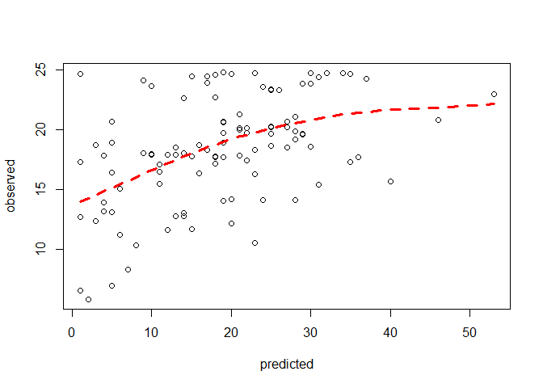

```r
scatter.smooth(hex_env$Sobs,hex_env$predS, lpars=list(col="red", lwd=3,lty=2),
               xlab="predicted",ylab="observed")
```

At the 4000 km² scale, the pattern of the observed and the predicted pattern appeared very similar. However, the predicted pattern at the 8000 km² and 20.000 km² scale strongly differ from the observed pattern. They clearly show that the GAM models tend to oversmooth at coarser spatial scales.

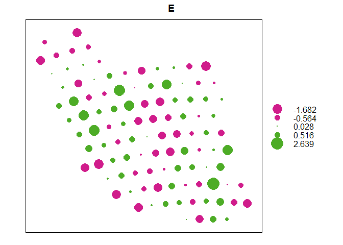

```r
E<-(resid(S.entropy,type="scaled.pearson"))
newdf2 <- newdf
mydata <- data.frame(E=E, X=newdf2$X,Y=newdf2$Y)
coordinates(mydata) <- ~ X + Y
proj4string(mydata) = CRS("+init=epsg:4326") ## set WGS84 as CRS

## bubble plot
bubble(mydata,"E")
```

```r
## isotropic variogram
E.vgm<- variogram(E~ X+Y, mydata)
E.vgm
```

```
##     np     dist     gamma dir.hor dir.ver   id
## 1  181 146.9194 0.6085162       0       0 var1
## 2   88 167.5833 0.7222262       0       0 var1
## 3  234 255.0733 0.8966831       0       0 var1
## 4  161 308.7481 0.6913155       0       0 var1
## 5  226 356.5040 0.8752535       0       0 var1
## 6  195 403.0652 0.7321213       0       0 var1
## 7  329 472.8318 0.7874429       0       0 var1
## 8  246 516.4877 0.8754070       0       0 var1
## 9  188 585.2322 0.8201512       0       0 var1
## 10 382 626.1628 0.8877135       0       0 var1
## 11 158 681.5596 0.8673354       0       0 var1
## 12 380 743.2934 0.9370232       0       0 var1
## 13 215 792.5957 0.8430978       0       0 var1
```

```r
E.fit = fit.variogram(E.vgm, model = vgm(1, "Sph", 900, 1))
E.fit
```

```
##   model     psill    range
## 1   Nug 0.0000000   0.0000
## 2   Sph 0.8355508 264.0621
```

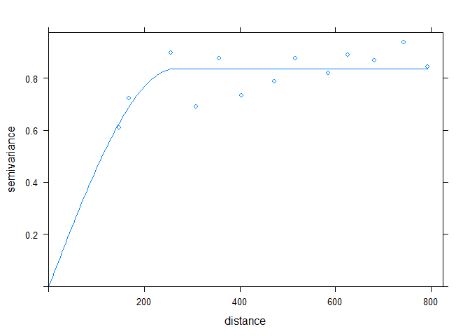

```r
plot(E.vgm, E.fit)
```

```r
## anisotropic variogram
E.vgm<- variogram(E~ X+Y, mydata, alpha=c(0,45,90,135))
E.vgm
```

```
##     np     dist       gamma dir.hor dir.ver   id
## 1   45 168.5163 0.769881196       0       0 var1
## 2   78 299.5293 0.765197684       0       0 var1
## 3   35 336.8582 0.989374702       0       0 var1
## 4    1 437.7601 0.004424279       0       0 var1
## 5  123 455.2462 0.815494902       0       0 var1
## 6   26 504.8582 0.943705072       0       0 var1
## 7   41 595.4013 0.846577212       0       0 var1
## 8  100 616.2647 0.723924761       0       0 var1
## 9   18 673.1282 0.902446454       0       0 var1
## 10  89 752.2878 0.777030063       0       0 var1
## 11  53 782.6165 0.881609919       0       0 var1
## 12  14 163.7233 0.278135994      45       0 var1
## 13  28 166.6046 0.621397027      45       0 var1
## 14  75 255.9584 0.820897200      45       0 var1
```

[output cut: 35 more lines]

```r
E.fit = fit.variogram(E.vgm, model = vgm(1, "Sph", 900, 1, anis = c(45, 0.5)))
E.fit
```

```
##   model     psill   range ang1 anis1
## 1   Nug 0.4061468   0.000    0   1.0
## 2   Sph 0.4281702 541.547   45   0.5
```

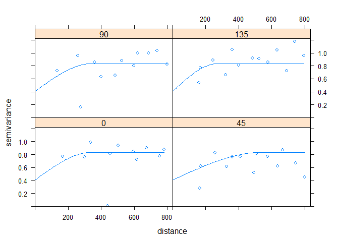

```r
plot(E.vgm, E.fit)
```

```r
### Correlgoram
ncf.cor <- correlog(mydata$X, mydata$Y, mydata$E, increment=50, resamp=999,latlon=T)
```

```
## 100  of  999
200  of  999
300  of  999
400  of  999
500  of  999
600  of  999
700  of  999
800  of  999
900  of  999
```

```r
## info
ncf.cor$n # number of observations per lag
```

```
##   3   4   5   6   7   8   9  10  11  12  13  14  15  16  17  18  19  20  21  22
##  91 178  89 190 191 235 135 351 201 153 376 164 269 293 194 237 230 224 164 248
##  23  24  25  26  27  28  29  30  31  32  33  34  35  36  37  38  39  40  41  42
## 152 138 184  92 133  83  77  69  40  59  35  31  36  21  20  22  11  13  13   5
##  43  44  45  46
##   7   3   1   2
```

```r
ncf.cor$mean.of.class # mean km per lag
```

```
##         3         4         5         6         7         8         9        10
##  133.3551  164.2075  244.0142  268.9848  323.5513  375.7838  417.1401  478.0563
##        11        12        13        14        15        16        17        18
##  520.9287  582.1277  621.0589  669.6624  730.1538  771.7630  829.4696  875.4159
##        19        20        21        22        23        24        25        26
##  923.5568  973.1692 1022.1586 1075.5213 1121.3485 1176.5306 1222.3061 1269.6827
##        27        28        29        30        31        32        33        34
## 1325.6780 1373.6744 1426.2224 1474.2285 1525.4537 1571.2503 1626.1818 1672.7571
##        35        36        37        38        39        40        41        42
## 1722.3251 1780.6538 1820.6944 1874.8361 1928.2715 1968.1151 2028.2359 2089.3023
##        43        44        45        46
## 2127.6249 2186.3568 2239.7289 2277.7549
```

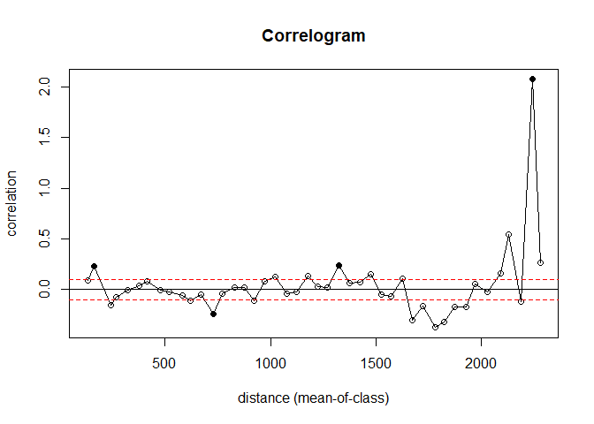

```r
## plot
plot(ncf.cor)
abline(h=0); abline(h=-0.1, col="red", lty=2); abline(h=0.1, col="red", lty=2)
```

The effect of spatial autocorrelation becomes stronger at this scale. However, the lags 3 and 4 (lag 1 and 2 do not exist) are still within a hexagonal cell, while the significance at larger lags (>650km) are already too far away to have an important effect given the low correlation values. Yet the validity of this model is unclear.

Still we save the best model for a comparison. Then we build a final summary table that allows us to compare the three models directly.

```r
best20000 <- S.entropy

tab_model(best4000, best8000, best20000, transform = NULL,
          show.df=F,
          show.se=F,
          show.ci=F,
          show.dev = T,
          dv.labels=c("S_4K", "S_8K","S_20K"))
```

|  | S_4K |  | S_8K |  | S_20K |  |
| --- | --- | --- | --- | --- | --- | --- |
| Predictors | Log-Mean | p | Log-Mean | p | Log-Mean | p |
| (Intercept) | 1.95 | **<0.001** | 2.36 | **<0.001** | 2.87 | **<0.001** |
| Smooth term (X,Y) | 30.31 | **<0.001** | 7.52 | **<0.001** | 0.00 | 0.742 |
| Smooth term (entropy) | 4.04 | **<0.001** | 2.42 | **0.001** | 4.42 | **<0.001** |
| Smooth term (corr) | 0.94 | **<0.001** | 2.70 | **<0.001** |  |  |
| Observations | 403 |  | 228 |  | 105 |  |
| R<sup>2</sup> | 0.279 |  | 0.195 |  | 0.172 |  |
| Deviance | 376.232 |  | 228.717 |  | 108.934 |  |

## Summary

Several things can be learnt from this study.

1. Model quality decreases with scale.
2. Effects like multicollinearity and spatial autocorrelation increase with scale. Note that the spatial interaction does not appear significant at the coarsest scale.
3. Models at higher spatial scales over-smooth the observed pattern
4. The most reliable scale was 4000km².
5. Habitat heterogeneity, and in particular the Entropy of the EVI in a area of 1km² is, when scaled to larger areas such as hexagonal grid cells, was superior in explaining the richness pattern of reptiles in Iran.
6. The spatial pattern revealed showed several hotspots which are in the Zagros and Alborz Mts. and to a little extent the more arid mountain ranges in the south-east.